# Applied ML - 2019

Josh Muncke

Jan 15 - Jan 16, 2019

```r
library(tidymodels)
library(tidyverse)

library(AmesHousing)
library(skimr)
library(ggridges)

theme_set(theme_bw())
```

# Applied Machine Learning - rstudio::conf 2019

Working materials for the *Applied Machine Learning* workshop given at rstudio::conf 2019 in Austin, Texas. Workshop materials available on Github *[here](https://github.com/topepo/rstudio-conf-2019)*.

## Background

- Two methods for specifying what terms to model. Not all models have both.
- Some models (99%) automatically generate dummies, some don’t.
- Sparse matrices can be used (unless they can’t).
- Different packages have different interfaces to call for the same requests.

### Different Philosophies - `caret`/`tidymodels`

`caret` is the primary package for *untidy* predictive modelling:

1. More traditional R coding style
2. High-level syntax
3. Comprehensive, less modular style
4. Many optimizations / easy to parallelize

`tidymodels` espouses the `tidyverse` approach:

1. Re-use existing data structures
2. Compose simple functions with the pipe `%>%`
3. Embrace functional programming
4. Design for humans (not machines)

`tidymodels` is a collection of tidy packages: `dials`, `infer`, `parsnip`, `recipes`, `rsample`, `yardstick`. Other packages are in development: `tidypredict`, `tidyposterior`, `tidytext`.

### Datasets used

- Ames IA housing data. 2,930 properties in the data, includes sale price with a bunch of other predictors.
- fueleconomy.gov data. 4,595 cars including fuel efficiency and some predictors.
- OKCupid data. 50,000 profiles with several types of fields including interests, descriptions, profession, diet, gender, languages etc. No usernames or pictures.

## Day 1

Read in Ames pricing data and process. Note use of `read_delim` and `rename_at`.

```r
ames_prices <- "http://bit.ly/2whgsQM" %>%
  read_delim(delim = "\t") %>%
  rename_at(vars(contains(' ')), funs(gsub(' ', '_', .))) %>%
  rename(Sale_Price = SalePrice) %>%
  filter(!is.na(Electrical)) %>%
  select(-Order, -PID, -Garage_Yr_Blt)

ames_prices %>%
  group_by(Alley) %>%
  summarize(
    mean_price = mean(Sale_Price / 1000),
    n = sum(!is.na(Sale_Price))
  )
```

```
## # A tibble: 3 x 3
##   Alley mean_price     n
##   <chr>      <dbl> <int>
## 1 Grvl        124.   120
## 2 Pave        177.    78
## 3 <NA>        183.  2731
```

### `purrr` is an under-utilized package!

Use `map()` instead of `lapply`/`vapply`.

`map` always returns a list, use suffixed versions if you knw what you want back e.g. `map_int`.

```r
library(purrr)

mini_ames <- ames_prices %>%
  select(Alley, Sale_Price, Yr_Sold) %>%
  filter(!is.na(Alley))

by_alley <- split(mini_ames, mini_ames$Alley)
map(by_alley, head, n = 2)
```

```
## $Grvl
## # A tibble: 2 x 3
##   Alley Sale_Price Yr_Sold
##   <chr>      <int>   <int>
## 1 Grvl       96500    2010
## 2 Grvl      109500    2010
##
## $Pave
## # A tibble: 2 x 3
##   Alley Sale_Price Yr_Sold
##   <chr>      <int>   <int>
## 1 Pave      190000    2010
## 2 Pave      155000    2010
```

```r
ames_lst_col <- nest(mini_ames, Alley) # Create a dataframe in a dataframe

ames_lst_col <- nest(mini_ames, -Alley)
ames_lst_col
```

```
## # A tibble: 2 x 2
##   Alley data
##   <chr> <list>
## 1 Pave  <tibble [78 x 2]>
## 2 Grvl  <tibble [120 x 2]>
```

```r
ames_lst_col %>%
  mutate(
    n_row = map_int(data, nrow),
    max   = map_dbl(data, ~max(.x$Sale_Price))
  )
```

```
## # A tibble: 2 x 4
##   Alley data               n_row    max
##   <chr> <list>             <int>  <dbl>
## 1 Pave  <tibble [78 x 2]>     78 345000
## 2 Grvl  <tibble [120 x 2]>   120 256000
```

### Quasiquotation

`quasiquotation` allows us to programatically insert arguments into an expression.

```r
mtcars %>% select(mpg, wt, hp)
```

```
##                      mpg    wt  hp
## Mazda RX4           21.0 2.620 110
## Mazda RX4 Wag       21.0 2.875 110
## Datsun 710          22.8 2.320  93
## Hornet 4 Drive      21.4 3.215 110
## Hornet Sportabout   18.7 3.440 175
## Valiant             18.1 3.460 105
## Duster 360          14.3 3.570 245
## Merc 240D           24.4 3.190  62
## Merc 230            22.8 3.150  95
## Merc 280            19.2 3.440 123
## Merc 280C           17.8 3.440 123
## Merc 450SE          16.4 4.070 180
## Merc 450SL          17.3 3.730 180
## Merc 450SLC         15.2 3.780 180
## Cadillac Fleetwood  10.4 5.250 205
## Lincoln Continental 10.4 5.424 215
## Chrysler Imperial   14.7 5.345 230
## Fiat 128            32.4 2.200  66
## Honda Civic         30.4 1.615  52
## Toyota Corolla      33.9 1.835  65
## Toyota Corona       21.5 2.465  97
## Dodge Challenger    15.5 3.520 150
## AMC Javelin         15.2 3.435 150
## Camaro Z28          13.3 3.840 245
## Pontiac Firebird    19.2 3.845 175
## Fiat X1-9           27.3 1.935  66
## Porsche 914-2       26.0 2.140  91
## Lotus Europa        30.4 1.513 113
## Ford Pantera L      15.8 3.170 264
## Ferrari Dino        19.7 2.770 175
## Maserati Bora       15.0 3.570 335
## Volvo 142E          21.4 2.780 109
```

```r
# What about this?
cols <- c("mpg","wt","hp")
value <- 5

mtcars %>% select(!!!cols) %>% mutate(value = !!value)
```

```
##     mpg    wt  hp value
## 1  21.0 2.620 110     5
## 2  21.0 2.875 110     5
## 3  22.8 2.320  93     5
## 4  21.4 3.215 110     5
## 5  18.7 3.440 175     5
## 6  18.1 3.460 105     5
## 7  14.3 3.570 245     5
## 8  24.4 3.190  62     5
## 9  22.8 3.150  95     5
## 10 19.2 3.440 123     5
## 11 17.8 3.440 123     5
## 12 16.4 4.070 180     5
## 13 17.3 3.730 180     5
## 14 15.2 3.780 180     5
```

[output cut: 18 more lines]

TRIPLE BANG (`!!!`) is used when you have a function that wants three dots (e.g. `select`) DOUBLE BANG (`!!`) is used when the argument can only have one value

### AmesHousing Exploration

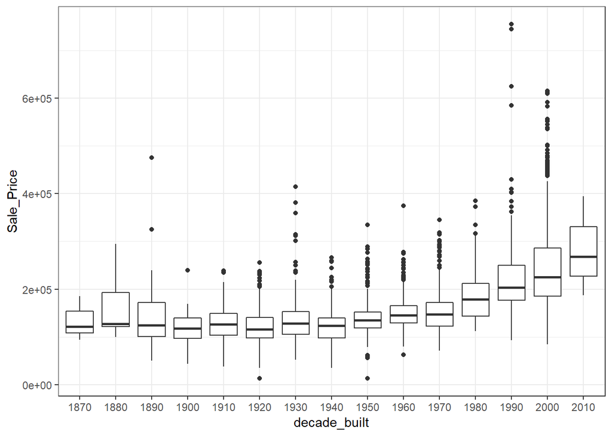

```r
ames <- AmesHousing::make_ames()
#ames %>% skimr::skim()

# Average bedrooms per pool type
ames %>%
  mutate(decade_built = as.factor(floor(Year_Built / 10) * 10)) %>%
  ggplot(aes(x = decade_built, y = Sale_Price)) +
  geom_boxplot() +
  theme_bw()
```

### Getting stuck in

Typical modelling process:

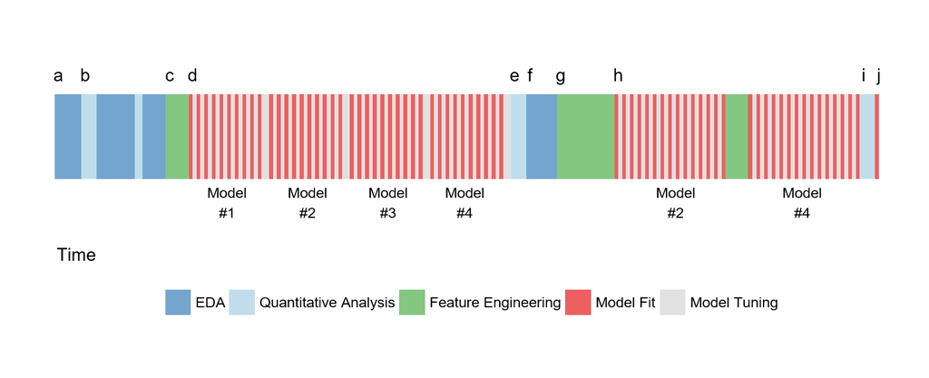

### Simple Linear Models

```r
library(AmesHousing)
ames <-
  make_ames() %>%
  dplyr::select(-matches("Qu"))

nrow(ames)
```

```
## [1] 2930
```

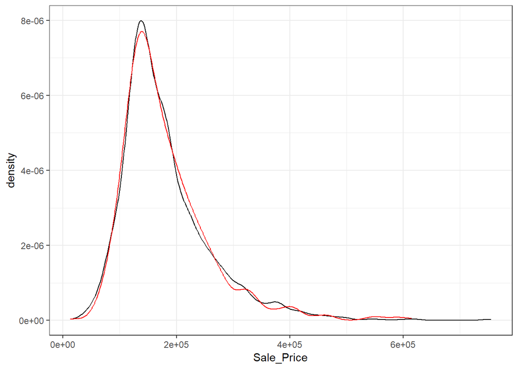

```r
set.seed(4595)

data_split <- initial_split(ames, strata = "Sale_Price")
ames_train <- training(data_split)
ames_test <- testing(data_split)

ggplot() +
  geom_line(data = ames_train,
            stat = "density",
            trim = TRUE,
            aes(x = Sale_Price)) +
    geom_line(data = ames_test,
            stat = "density",
            trim = TRUE,
            col = "red",
            aes(x = Sale_Price))
```

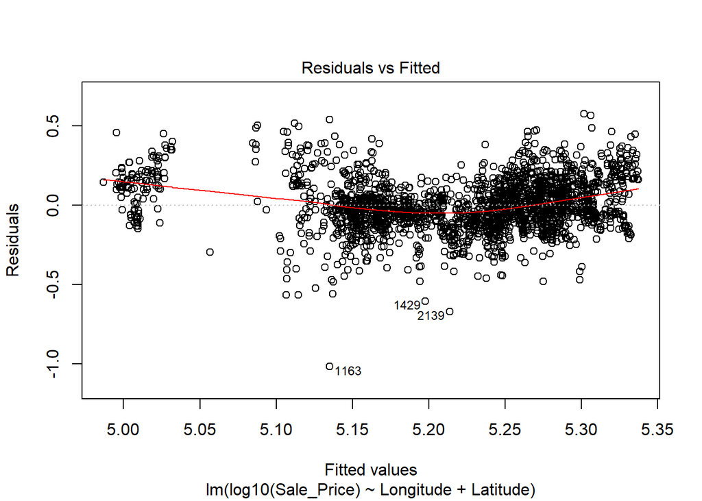

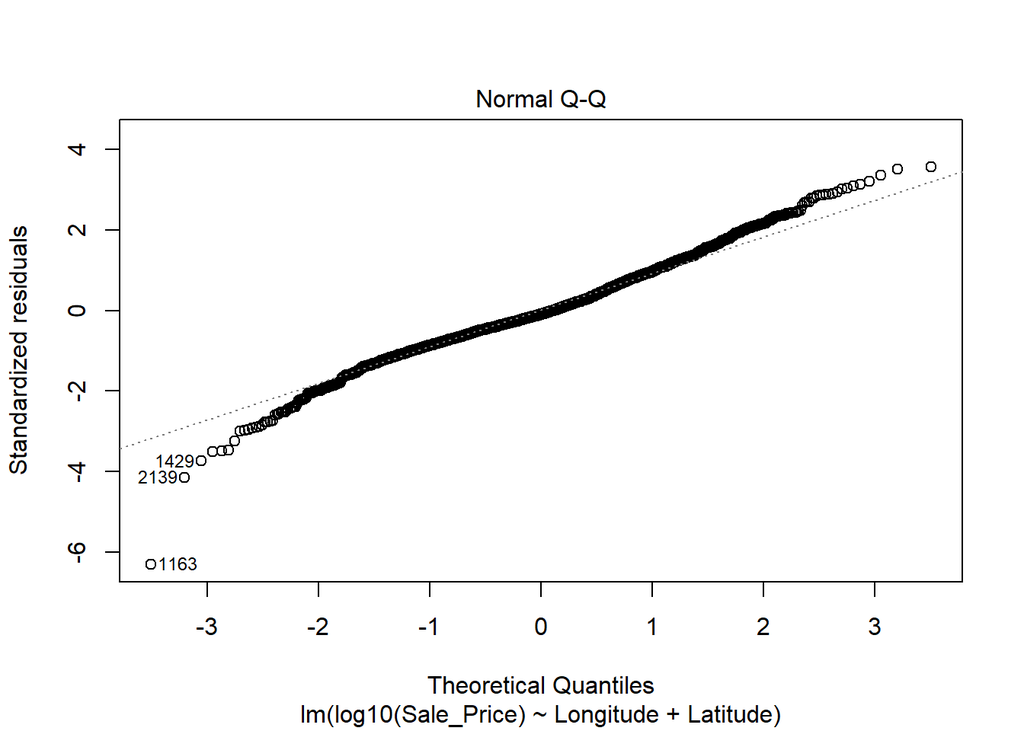

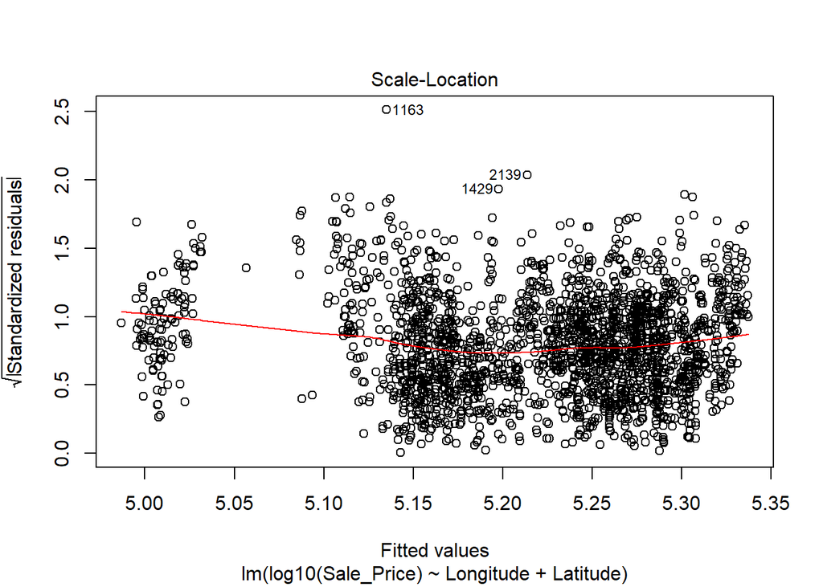

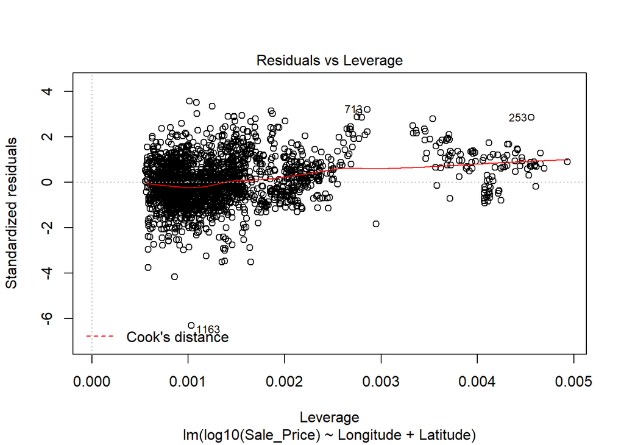

```r
simple_lm <- lm(log10(Sale_Price) ~ Longitude + Latitude, data = ames_train)
plot(simple_lm)
```

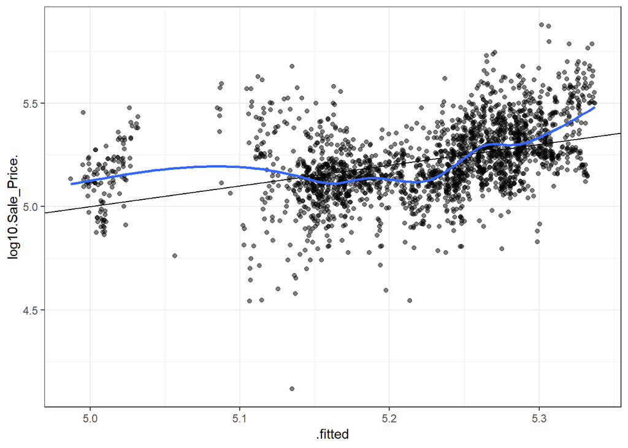

```r
simple_lm_values <- broom::augment(simple_lm) # Creates a nice data frame with values, predictors, residuals etc.

# Observed versus fitted
simple_lm_values %>%
  ggplot(aes(x = .fitted, y = log10.Sale_Price.)) +
  geom_point(alpha = 0.5) +
  geom_abline(slope = 1, intercept = 0) +
  geom_smooth(se = F)
```

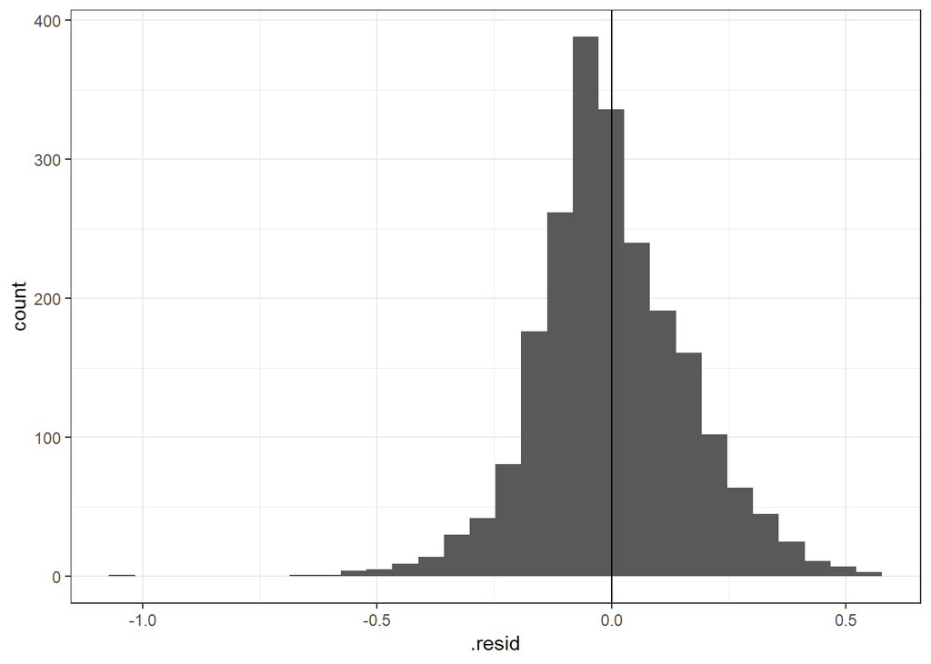

```r
simple_lm_values %>%
  ggplot(aes(x = .resid)) +
  geom_histogram() +
  geom_vline(xintercept = 0)
```

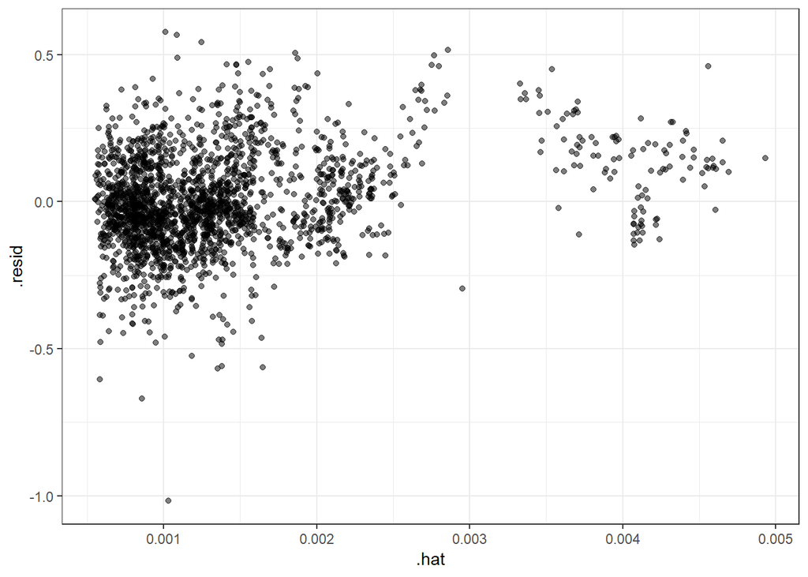

```r
# Hat values - distance to center of training set (e.g. center of town)
simple_lm_values %>%
  ggplot(aes(x = .hat, y = .resid)) +
  geom_point(alpha = 0.5)
```

### Parsnip

*A tidy, unified interface to models.*

Parsnip process:

- Create specification
- Set the engine
- Fit the model

```r
library(parsnip)

# We just want to do a linear regression
spec_lin_reg <- linear_reg()
spec_lin_reg
```

```
## Linear Regression Model Specification (regression)
```

```r
# Different engine types allow us to make the same TYPE of model
#  using different calculation engines
spec_lm <- spec_lin_reg %>% set_engine("lm")
spec_lm
```

```
## Linear Regression Model Specification (regression)
##
## Computational engine: lm
```

```r
spec_stan <- spec_lin_reg %>% set_engine("stan", chains = 4, iter = 1000)
spec_stan
```

```
## Linear Regression Model Specification (regression)
##
## Engine-Specific Arguments:
##   chains = 4
##   iter = 1000
##
## Computational engine: stan
```

```r
# Fitting process is identical - just pass different specifications
fit_lm <- parsnip::fit(
  spec_lm,
  log10(Sale_Price) ~ Latitude + Latitude,
  data = ames_train
)

fit_stan <- parsnip::fit(
  spec_stan,
  log10(Sale_Price) ~ Latitude + Latitude,
  data = ames_train
)
coef(fit_lm$fit)
```

```
## (Intercept)    Latitude
## -118.707728    2.948223
```

```r
coef(fit_stan$fit)
```

```
## (Intercept)    Latitude
## -118.588776    2.945376
```

```r
summary(fit_lm$fit)
```

```
##
## Call:
## stats::lm(formula = formula, data = data)
##
## Residuals:
##      Min       1Q   Median       3Q      Max
## -1.05580 -0.10269 -0.02041  0.11646  0.60708
##
## Coefficients:
##              Estimate Std. Error t value Pr(>|t|)
## (Intercept) -118.7077     8.3161  -14.27   <2e-16 ***
## Latitude       2.9482     0.1978   14.90   <2e-16 ***
## ---
## Signif. codes:  0 '***' 0.001 '**' 0.01 '*' 0.05 '.' 0.1 ' ' 1
##
## Residual standard error: 0.1699 on 2197 degrees of freedom
## Multiple R-squared:  0.0918, Adjusted R-squared:  0.09139
## F-statistic: 222.1 on 1 and 2197 DF,  p-value: < 2.2e-16
```

```r
summary(fit_stan$fit)
```

```
##
## Model Info:
##
##  function:     stan_glm
##  family:       gaussian [identity]
##  formula:      log10(Sale_Price) ~ Latitude + Latitude
##  algorithm:    sampling
##  priors:       see help('prior_summary')
##  sample:       2000 (posterior sample size)
##  observations: 2199
##  predictors:   2
##
## Estimates:
##                 mean   sd     2.5%   25%    50%    75%    97.5%
## (Intercept)   -118.8    8.1 -135.1 -124.3 -118.6 -113.3 -103.5
## Latitude         3.0    0.2    2.6    2.8    2.9    3.1    3.3
## sigma            0.2    0.0    0.2    0.2    0.2    0.2    0.2
## mean_PPD         5.2    0.0    5.2    5.2    5.2    5.2    5.2
## log-posterior  769.6    1.2  766.4  769.1  769.9  770.5  771.0
##
## Diagnostics:
##               mcse Rhat n_eff
## (Intercept)   0.2  1.0  1601
## Latitude      0.0  1.0  1601
## sigma         0.0  1.0  1335
## mean_PPD      0.0  1.0  2137
## log-posterior 0.0  1.0   934
##
## For each parameter, mcse is Monte Carlo standard error, n_eff is a crude measure of effective sample size, and Rhat is the potential scale reduction factor on split chains (at convergence Rhat=1).
```

### Resampling

*N.B. on terminology:* Training/test is the split on the top-level data, Analysis/assessment is the split *inside* the resample.

#### V-fold cross validation

- Embarrassingly parallel
- Always just use 10-folds
- Each data point only used in *one* assessment set

*Max tends to favor 5 REPEATS of 10-fold cross-validation.*

For example 10% of the Ames data is approx. 219 data points - probably good to estimate RMSE and R^2.

#### Bootstrap

Bootstrap has good variance properties but bias is poor.

- Analysis set: each point is selected with replacement
- Assessment set: unique points not selected in the Analysis set